# Prices

Ryan Farhab

2022-09-15

This is the R markdown (rmd) exercise file that accompanies the lecture notes. It will be your sandbox! Fill in the R code chunks, experiment, and have fun!

# Importing Data

### Import from csv file

Download the data of the stock of your choice from Yahoo Finance, and read it in using read.csv():

```r
data_csv=read.csv("DWAC.csv",header=TRUE)
```

Importatn note: when downloading the data, right click the download link and “save link as” to save to file to the same folder as your rmd file. If you open the csv file in Excel, do NOT save it or “save as”, because doing so will will mess up the csv date format, and you will encounter error in converting the date column in a later exercise. If that happens, you need to download the csv file again.

### The Data Frame

Use head() and tail() to study the data frame you have just imported.

```r
head(data_csv)
```

```
##         Date  Open  High   Low Close Adj.Close Volume
## 1 2021-09-30 16.00 17.33 9.900 9.950     9.950 296100
## 2 2021-10-01 10.00 11.00 9.910 9.940     9.940 153100
## 3 2021-10-04  9.92 10.05 9.900 9.920     9.920  24300
## 4 2021-10-05 10.02 10.02 9.907 9.928     9.928   8100
## 5 2021-10-06  9.90  9.94 9.840 9.920     9.920  18600
## 6 2021-10-07  9.94  9.98 9.940 9.967     9.967 634800
```

```r
tail(data_csv)
```

```
##           Date  Open  High   Low Close Adj.Close  Volume
## 236 2022-09-07 20.78 23.30 20.75 23.07     23.07 1571000
## 237 2022-09-08 22.75 25.00 22.51 23.35     23.35 1799100
## 238 2022-09-09 24.37 24.49 22.70 24.00     24.00 1772700
## 239 2022-09-12 23.85 24.27 23.61 24.10     24.10  509100
## 240 2022-09-13 23.60 25.00 23.60 24.49     24.49  638200
## 241 2022-09-14 24.57 24.57 23.96 24.19     24.19  422000
```

### The Date Column

Convert the Date column of the data frame from factor to “Date”:

```r
data_csv$Date=as.Date(data_csv$Date)

class(data_csv$Date)
```

```
## [1] "Date"
```

### Converting Data Frame to XTS

Convert your data frame to xts:

```r
library(xts)
stockdata_csv=xts(
  xts(data_csv[ ,2:7], order.by=data_csv[ ,1])

)
head(stockdata_csv)
```

```
##             Open  High   Low Close Adj.Close Volume
## 2021-09-30 16.00 17.33 9.900 9.950     9.950 296100
## 2021-10-01 10.00 11.00 9.910 9.940     9.940 153100
## 2021-10-04  9.92 10.05 9.900 9.920     9.920  24300
## 2021-10-05 10.02 10.02 9.907 9.928     9.928   8100
## 2021-10-06  9.90  9.94 9.840 9.920     9.920  18600
## 2021-10-07  9.94  9.98 9.940 9.967     9.967 634800
```

About xts: https://joshuaulrich.github.io/xts/xts_faq.html

More on xts: https://ugoproto.github.io/ugo_r_doc/Time+Series+in+R+The+Power+of+xts+and+zoo/

### Renaming Columns

Rename the columns of your xts to use the stock’s ticker symbol as prefix:

```r
names(stockdata_csv)=c("dwac.open","dwac.high","dwac.low","dwac.close","dwac.adjusted","dwac.volume")
stockdata_csv=stockdata_csv[ ,c("dwac.open","dwac.high","dwac,low","dwac.close","dwac.volume","dwac.adjusted")]
```

At this point, the xts data you contructured should be the same as the xts imported directly using quantmod library. Which way do you prefer?

### Import directly using quantmod

Select any stock other than AMZN. Download the data using getSymbols().

```r
library(quantmod)
stock_data2= getSymbols ("MSFT",from="2010-12-31",to="2013-12-31",auto.assign=FALSE)
class(stock_data2)
```

```
## [1] "xts" "zoo"
```

### The xts object

Use head() and tail() to study the data imported.

```r
head(stock_data2,6)
```

```
##            MSFT.Open MSFT.High MSFT.Low MSFT.Close MSFT.Volume MSFT.Adjusted
## 2010-12-31     27.80     27.92    27.63      27.91    24752000      21.86310
## 2011-01-03     28.05     28.18    27.92      27.98    53443800      21.91792
## 2011-01-04     27.94     28.17    27.85      28.09    54405600      22.00409
## 2011-01-05     27.90     28.01    27.77      28.00    58998700      21.93359
## 2011-01-06     28.04     28.85    27.86      28.82    88026300      22.57594
## 2011-01-07     28.64     28.74    28.25      28.60    73762000      22.40360
```

```r
tail(stock_data2,6)
```

```
##            MSFT.Open MSFT.High MSFT.Low MSFT.Close MSFT.Volume MSFT.Adjusted
## 2013-12-20     36.20     36.93    36.19      36.80    62649100      31.35055
## 2013-12-23     36.81     36.89    36.55      36.62    25128700      31.19721
## 2013-12-24     36.72     37.17    36.64      37.08    14243000      31.58908
## 2013-12-26     37.20     37.49    37.17      37.44    17612800      31.89577
## 2013-12-27     37.58     37.62    37.17      37.29    14563000      31.76798
## 2013-12-30     37.22     37.38    36.90      37.29    16290500      31.76798
```

### A quick summary

Use the summarizing functions dim(), str(), summary() on your data:

```r
dim(stock_data2)
```

```
## [1] 754   6
```

```r
str(stock_data2)
```

```
## An 'xts' object on 2010-12-31/2013-12-30 containing:
##   Data: num [1:754, 1:6] 27.8 28 27.9 27.9 28 ...
##  - attr(*, "dimnames")=List of 2
##   ..$ : NULL
##   ..$ : chr [1:6] "MSFT.Open" "MSFT.High" "MSFT.Low" "MSFT.Close" ...
##   Indexed by objects of class: [Date] TZ: UTC
##   xts Attributes:
## List of 2
##  $ src    : chr "yahoo"
##  $ updated: POSIXct[1:1], format: "2022-09-15 22:34:17"
```

```r
summary(stock_data2)
```

```
##      Index              MSFT.Open       MSFT.High        MSFT.Low
##  Min.   :2010-12-31   Min.   :23.75   Min.   :24.01   Min.   :23.65
##  1st Qu.:2011-09-29   1st Qu.:26.68   1st Qu.:26.94   1st Qu.:26.46
##  Median :2012-06-28   Median :28.84   Median :29.06   Median :28.54
##  Mean   :2012-06-30   Mean   :29.43   Mean   :29.68   Mean   :29.17
##  3rd Qu.:2013-04-02   3rd Qu.:31.79   3rd Qu.:32.01   3rd Qu.:31.55
##  Max.   :2013-12-30   Max.   :38.85   Max.   :38.98   Max.   :38.37
##    MSFT.Close     MSFT.Volume        MSFT.Adjusted
##  Min.   :23.71   Min.   : 14243000   Min.   :18.81
##  1st Qu.:26.69   1st Qu.: 38323900   1st Qu.:21.35
##  Median :28.80   Median : 48414150   Median :23.70
##  Mean   :29.44   Mean   : 52433844   Mean   :24.08
##  3rd Qu.:31.80   3rd Qu.: 59317900   3rd Qu.:26.00
##  Max.   :38.94   Max.   :319317900   Max.   :33.17
```

# Manipulating the xts data

### Some Exercises to Manipulate the xts data

Try the different ways to subset your xts data:

```r
stock_data2[1:10]
stock_data2[1:4,c(3:4)]

(nrow(stock_data2)-9):nrow(stock_data2)

#stock_data2$MSFT.Volume
```

[output not shown]

```r
Cl(stock_data2)[1:3]
```

```
##            MSFT.Close
## 2010-12-31      27.91
## 2011-01-03      27.98
## 2011-01-04      28.09
```

```r
Ad(stock_data2)[1:3]
```

```
##            MSFT.Adjusted
## 2010-12-31      21.86310
## 2011-01-03      21.91792
## 2011-01-04      22.00409
```

### Advantage of XTS: Subsetting time

### Subsetting time

Experiment the different ways to subset time with an xts object:

```r
stock_data2["2010-12-31/2011-01-10"]
```

```
##            MSFT.Open MSFT.High MSFT.Low MSFT.Close MSFT.Volume MSFT.Adjusted
## 2010-12-31     27.80     27.92    27.63      27.91    24752000      21.86310
## 2011-01-03     28.05     28.18    27.92      27.98    53443800      21.91792
## 2011-01-04     27.94     28.17    27.85      28.09    54405600      22.00409
## 2011-01-05     27.90     28.01    27.77      28.00    58998700      21.93359
## 2011-01-06     28.04     28.85    27.86      28.82    88026300      22.57594
## 2011-01-07     28.64     28.74    28.25      28.60    73762000      22.40360
## 2011-01-10     28.26     28.40    28.04      28.22    57573600      22.10592
```

### first() and last()

```r
# get the first 1 week of your data:
stock_data2["2010-12-31/2011-01-10"]
```

```
##            MSFT.Open MSFT.High MSFT.Low MSFT.Close MSFT.Volume MSFT.Adjusted
## 2010-12-31     27.80     27.92    27.63      27.91    24752000      21.86310
## 2011-01-03     28.05     28.18    27.92      27.98    53443800      21.91792
## 2011-01-04     27.94     28.17    27.85      28.09    54405600      22.00409
## 2011-01-05     27.90     28.01    27.77      28.00    58998700      21.93359
## 2011-01-06     28.04     28.85    27.86      28.82    88026300      22.57594
## 2011-01-07     28.64     28.74    28.25      28.60    73762000      22.40360
## 2011-01-10     28.26     28.40    28.04      28.22    57573600      22.10592
```

```r
# get the first 3 days of the last 2 weeks of your data:
first(last(stock_data2,"2 weeks"),"3 days")
```

```
##            MSFT.Open MSFT.High MSFT.Low MSFT.Close MSFT.Volume MSFT.Adjusted
## 2013-12-23     36.81     36.89    36.55      36.62    25128700      31.19721
## 2013-12-24     36.72     37.17    36.64      37.08    14243000      31.58908
## 2013-12-26     37.20     37.49    37.17      37.44    17612800      31.89577
```

### Downsampling

Exercise: figure out how to downsample to weekly frequency.

```r
#to.weekly(stock_data2)
```

# Plotting XTS

### Line Plot

```r
stock_data_monthly=to.monthly(stock_data2)
head(stock_data_monthly)
```

```
##          stock_data2.Open stock_data2.High stock_data2.Low stock_data2.Close
## Dec 2010            27.80            27.92           27.63             27.91
## Jan 2011            28.05            29.46           27.42             27.73
## Feb 2011            27.80            28.34           26.43             26.58
## Mar 2011            26.60            26.78           24.68             25.39
## Apr 2011            25.53            26.87           24.72             25.92
## May 2011            25.94            26.25           24.03             25.01
##          stock_data2.Volume stock_data2.Adjusted
## Dec 2010           24752000             21.86310
## Jan 2011         1361258700             21.72209
## Feb 2011         1114368500             20.94431
## Mar 2011         1310885200             20.00663
## Apr 2011         1313844800             20.42426
## May 2011         1364062800             19.83638
```

Plot the closing prices of your stock:

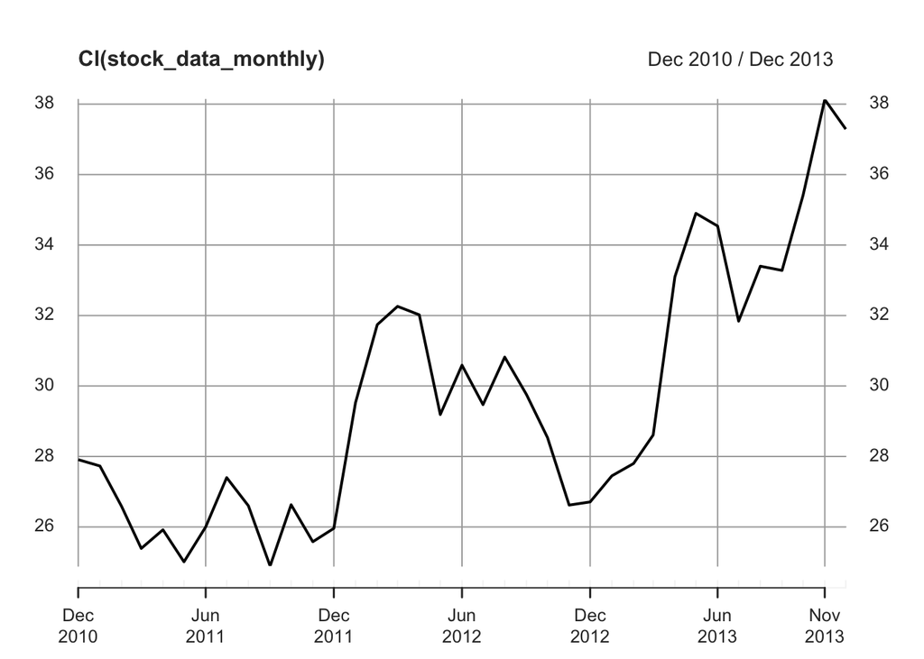

```r
plot(Cl(stock_data_monthly))
```

### Candlestick

Create candle stick chart for your stock for a given month. Experiment with the different themes.

[figure not shown]

```r
library(quantmod)

chartSeries(stock_data_monthly["2012-06",],theme="black",name="TSLA Cl")
```

### Compare to S&P500

Download S&P500 using getSymbols from the quantmod library. Combine the S&P500 adjusted close with the adjusted close of your stock:

```r
gspc=getSymbols("^GSPC",from="2010-12-31",to="2013-12-31",auto.assign = FALSE)

head(gspc)
```

```
##            GSPC.Open GSPC.High GSPC.Low GSPC.Close GSPC.Volume GSPC.Adjusted
## 2010-12-31   1256.76   1259.34  1254.19    1257.64  1799770000       1257.64
## 2011-01-03   1257.62   1276.17  1257.62    1271.87  4286670000       1271.87
## 2011-01-04   1272.95   1274.12  1262.66    1270.20  4796420000       1270.20
## 2011-01-05   1268.78   1277.63  1265.36    1276.56  4764920000       1276.56
## 2011-01-06   1276.29   1278.17  1270.43    1273.85  4844100000       1273.85
## 2011-01-07   1274.41   1276.83  1261.70    1271.50  4963110000       1271.50
```

```r
close.prices=cbind(Ad(gspc),Ad(stock_data2))
```

### Price Paths

Plot the price paths:

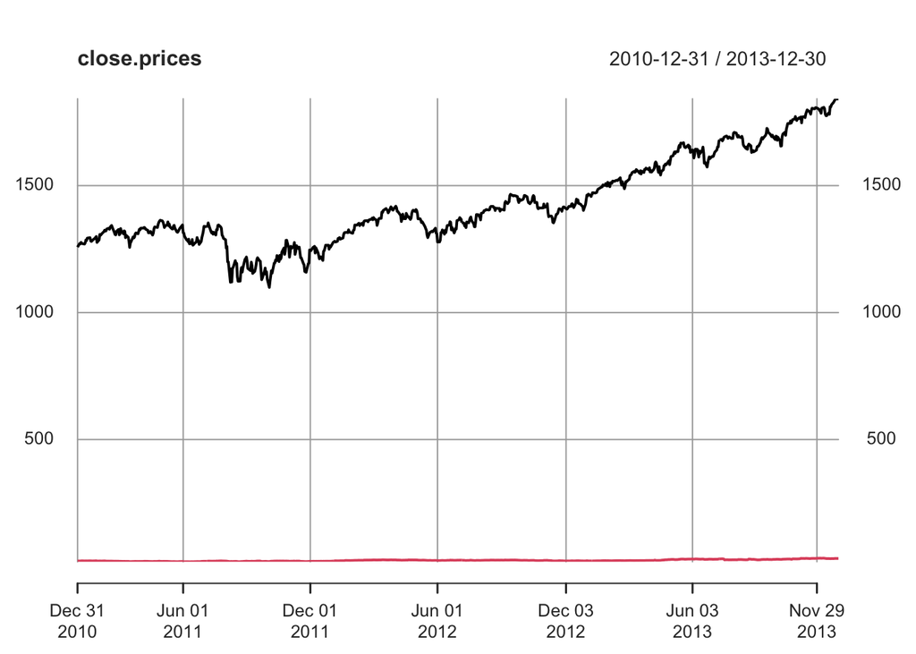

```r
plot(close.prices)
```

### Normalization

Normalize the starting prices to be $1:

```r
library(quantmod)

normalised.closed.prices=cbind(Ad(gspc)/as.numeric(Ad(gspc)[1]),Ad(stock_data2)/as.numeric(Ad(stock_data2)[1]))
```

### Normalized Price Paths

Plot the normalize price paths:

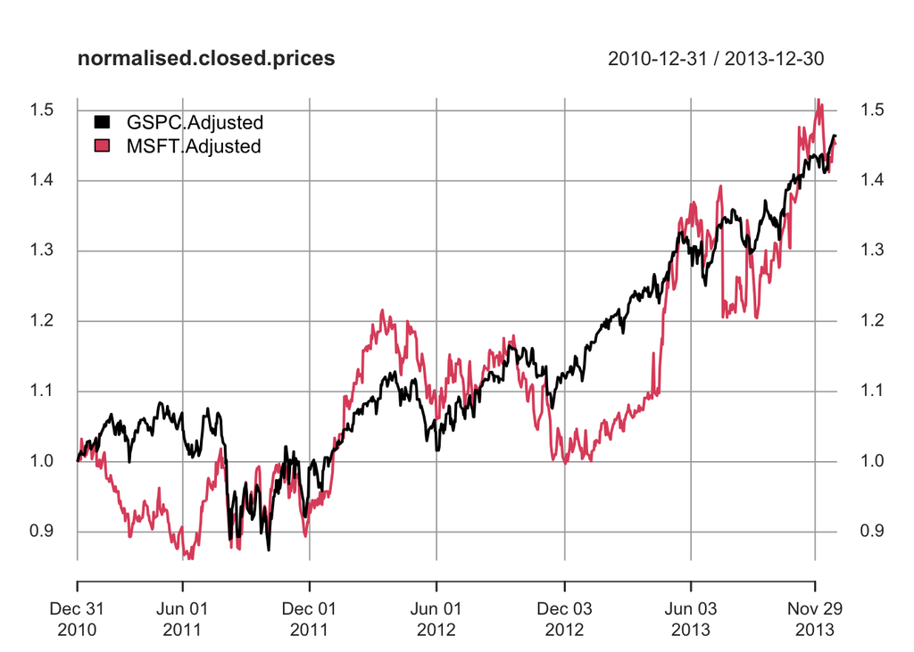

```r
plot(normalised.closed.prices,legend.loc="topleft")
```

# Technical Indicators

## Simple Moving Average (SMA)

### Simple Moving Average (SMA)

Readings on SMA: https://www.fidelity.com/learning-center/trading-investing/technical-analysis/technical-indicator-guide/sma

### Calculate SMA

Calculate the 50-day moving average for your stock:

```r
x=Cl(stock_data2)
```

```r
head(x)
```

```
##            MSFT.Close
## 2010-12-31      27.91
## 2011-01-03      27.98
## 2011-01-04      28.09
## 2011-01-05      28.00
## 2011-01-06      28.82
## 2011-01-07      28.60
```

```r
names(x)="close"
```

```r
x$sma=rollmeanr(x$close,k=50)
```

Another function that calculates the rolling mean is the rollmean() function. Can you find out difference between rollmean() and rollmeanr()?

```r
d=rollmean(x$close,k=50)
```

```r
head(d)
```

```
##              close
## 2011-02-04 27.4406
## 2011-02-07 27.3902
## 2011-02-08 27.3264
## 2011-02-09 27.2602
## 2011-02-10 27.1962
## 2011-02-11 27.1264
```

```r
head(x)
```

```
##            close sma
## 2010-12-31 27.91  NA
## 2011-01-03 27.98  NA
## 2011-01-04 28.09  NA
## 2011-01-05 28.00  NA
## 2011-01-06 28.82  NA
## 2011-01-07 28.60  NA
```

In a spreadsheet, how would you calculate the moving average?

### Plot the SMA

Make a plot of the SMA:

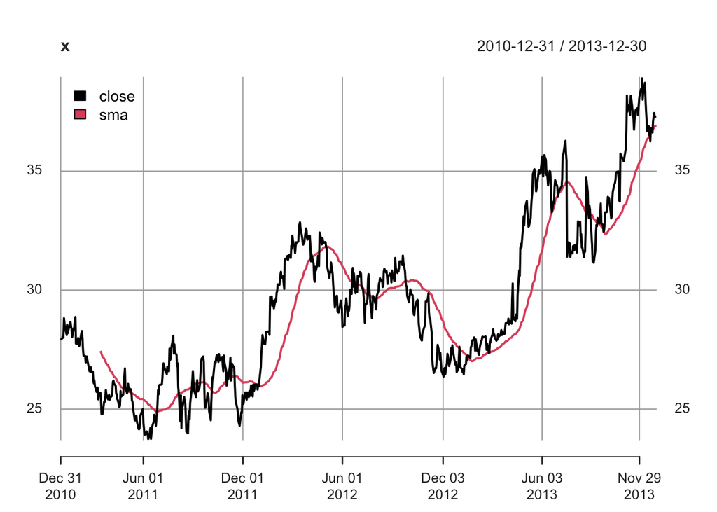

```r
plot(x,legend.loc="topleft")
```

### Make it a function!

Turn the SMA code into a function:

```r
mysma=function(stock_data2){
    x=Cl(stock_data2)
    names(x)="close"
    x$sma=rollmeanr(x$close,k=50)
    retun=(x$sma)
}
```

### Test the function

Test your function to see if it can generate the same plot:

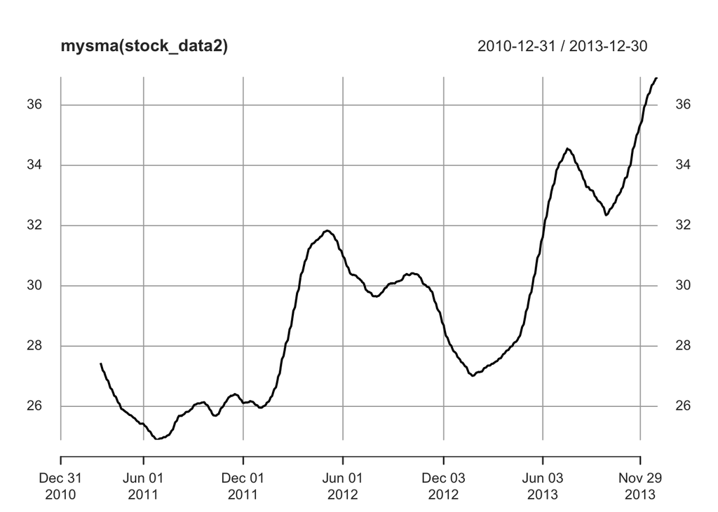

```r
plot(mysma(stock_data2))
```

### Make it a flexible function

```r
mysma=function(stock_data2,k){
    x=Cl(stock_data2)
    names(x)="close"
    x$sma=rollmeanr(x$close,k=50)
    retun=(x$sma)
}
```

### Test the flexible function

```r
mysma(stock_data2,k=10)
```

[figure not shown]

```r
plot(stock_data2,k=10)
```

### SMA Crossing

```r
data_to_plot=cbind(
  Cl(stock_data2),
  mysma(stock_data2,k=50),
  mysma(stock_data2,k=200)
)
```

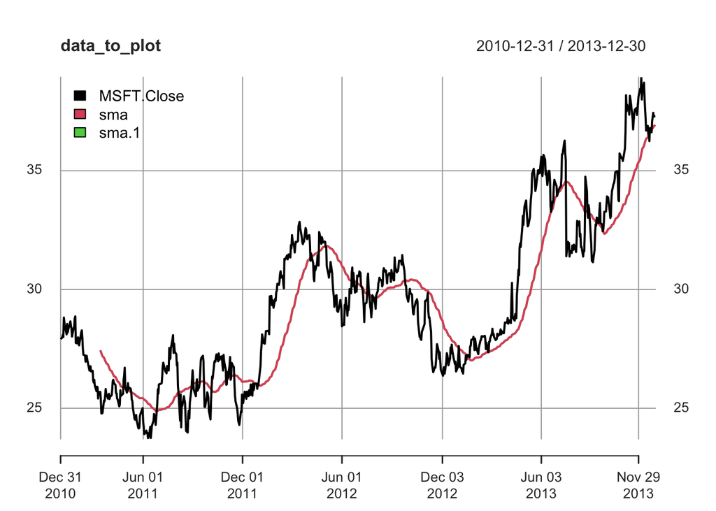

```r
plot(data_to_plot,legend.loc="topleft")
```

What is your intepretation?

## Bollinger Bands

### Bollinger Bands

Learn about Bollinger Bands: https://www.fidelity.com/learning-center/trading-investing/technical-analysis/technical-indicator-guide/bollinger-bands

### Bollinger Bands Example

Clifford Ang’s text (Chapte 1) talks about how to create the Bollinger Bands. Let’s try to implement it in R.

### Implementing the Bollinger Bands

Calculate the Bollinger Bands:

```r
y=Cl(stock_data2)
names(y)="price"
```

```r
y$avg=rollmeanr(y$price,k=20)
```

```r
head(y,n=22)
```

```
##            price     avg
## 2010-12-31 27.91      NA
## 2011-01-03 27.98      NA
## 2011-01-04 28.09      NA
## 2011-01-05 28.00      NA
## 2011-01-06 28.82      NA
## 2011-01-07 28.60      NA
## 2011-01-10 28.22      NA
## 2011-01-11 28.11      NA
## 2011-01-12 28.55      NA
## 2011-01-13 28.19      NA
## 2011-01-14 28.30      NA
## 2011-01-18 28.66      NA
## 2011-01-19 28.47      NA
## 2011-01-20 28.35      NA
## 2011-01-21 28.02      NA
## 2011-01-24 28.38      NA
## 2011-01-25 28.45      NA
## 2011-01-26 28.78      NA
## 2011-01-27 28.87      NA
## 2011-01-28 27.75 28.3250
## 2011-01-31 27.73 28.3160
## 2011-02-01 27.99 28.3165
```

```r
y$sd=rollapplyr(y$price,width=20,FUN=sd)
```

```r
y$sd2up=y$avg+2*y$sd
```

```r
y$sd2dw=y$avg-2*y$sd
```

```r
head(y,n=20)
```

```
##            price    avg        sd    sd2up    sd2dw
## 2010-12-31 27.91     NA        NA       NA       NA
## 2011-01-03 27.98     NA        NA       NA       NA
## 2011-01-04 28.09     NA        NA       NA       NA
## 2011-01-05 28.00     NA        NA       NA       NA
## 2011-01-06 28.82     NA        NA       NA       NA
## 2011-01-07 28.60     NA        NA       NA       NA
## 2011-01-10 28.22     NA        NA       NA       NA
## 2011-01-11 28.11     NA        NA       NA       NA
## 2011-01-12 28.55     NA        NA       NA       NA
## 2011-01-13 28.19     NA        NA       NA       NA
## 2011-01-14 28.30     NA        NA       NA       NA
## 2011-01-18 28.66     NA        NA       NA       NA
## 2011-01-19 28.47     NA        NA       NA       NA
## 2011-01-20 28.35     NA        NA       NA       NA
## 2011-01-21 28.02     NA        NA       NA       NA
## 2011-01-24 28.38     NA        NA       NA       NA
## 2011-01-25 28.45     NA        NA       NA       NA
## 2011-01-26 28.78     NA        NA       NA       NA
## 2011-01-27 28.87     NA        NA       NA       NA
## 2011-01-28 27.75 28.325 0.3227922 28.97058 27.67942
```

### Plot the Bollinger Bands

Plot the Bollinger Bands:

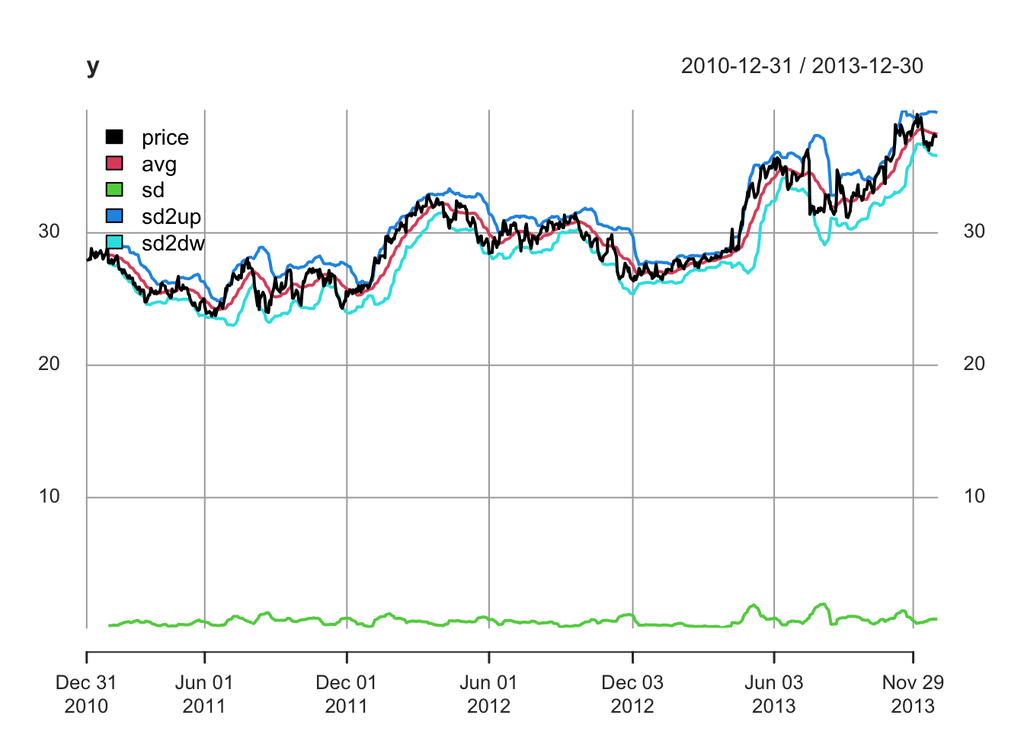

```r
plot(y,legend.loc="topleft")
```

## Relative Strength Indicator (RSI)

### RSI Definition

Learn about RSI:

http://stockcharts.com/school/doku.php?id=chart_school:technical_indicators:relative_strength_index_rsi

https://www.fidelity.com/learning-center/trading-investing/technical-analysis/technical-indicator-guide/RSI

### RSI Example

Clifford Ang’s text (Chapte 1) talks about how to create the RSI technical indicator. Let’s implement it in R here.

### RSI Calculation 1

Select the closing price, calculate the change in price for up days and down days:

```r
z=Cl(stock_data2)
names(z)="price"
```

```r
z$delta=diff(z$price)
```

```r
z$up=ifelse(z$delta>0,1,0)
z$dw=ifelse(z$delta<0,1,0)
```

```r
z$up.val=z$delta*z$up
z$dw.val=z$delta*z$dw
```

### RSI Calculation 2

Calculate the rolling average gain and average loss:

```r
z$up.avg=NA
z$up.avg[15]=mean(z$up.val[2:15])
z$dw.avg=NA
z$dw.avg[15]=mean(z$dw.val[2:15])
```

```r
for(i in 16:nrow(z)){
z$up.avg[i]=(as.numeric(z$up.avg[i-1])*13+as.numeric(z$up.val[i])*1)/14
z$dw.avg[i]=(as.numeric(z$dw.avg[i-1])*13+as.numeric(z$dw.val[i])*1)/14
}
```

```r
head(z,n=16)
```

```
##            price     delta up dw   up.val    dw.val    up.avg     dw.avg
## 2010-12-31 27.91        NA NA NA       NA        NA        NA         NA
## 2011-01-03 27.98  0.070000  1  0 0.070000  0.000000        NA         NA
## 2011-01-04 28.09  0.110000  1  0 0.110000  0.000000        NA         NA
## 2011-01-05 28.00 -0.090000  0  1 0.000000 -0.090000        NA         NA
## 2011-01-06 28.82  0.820000  1  0 0.820000  0.000000        NA         NA
## 2011-01-07 28.60 -0.220000  0  1 0.000000 -0.220000        NA         NA
## 2011-01-10 28.22 -0.380001  0  1 0.000000 -0.380001        NA         NA
## 2011-01-11 28.11 -0.109998  0  1 0.000000 -0.109998        NA         NA
## 2011-01-12 28.55  0.439998  1  0 0.439998  0.000000        NA         NA
## 2011-01-13 28.19 -0.359998  0  1 0.000000 -0.359998        NA         NA
## 2011-01-14 28.30  0.109998  1  0 0.109998  0.000000        NA         NA
## 2011-01-18 28.66  0.360001  1  0 0.360001  0.000000        NA         NA
## 2011-01-19 28.47 -0.190001  0  1 0.000000 -0.190001        NA         NA
## 2011-01-20 28.35 -0.119999  0  1 0.000000 -0.119999        NA         NA
## 2011-01-21 28.02 -0.330000  0  1 0.000000 -0.330000 0.1364284 -0.1285712
## 2011-01-24 28.38  0.359999  1  0 0.359999  0.000000 0.1523977 -0.1193876
```

### RSI Calculation 3

Calculate RS and RSI:

```r
z$RS=z$up.avg/z$dw.avg
```

```r
z$RSI=100-100/(1+z$RS)
```

```r
tail(z)
```

```
##            price     delta up dw   up.val    dw.val    up.avg     dw.avg
## 2013-12-20 36.80  0.549999  1  0 0.549999  0.000000 0.1829222 -0.2084138
## 2013-12-23 36.62 -0.180000  0  1 0.000000 -0.180000 0.1698563 -0.2063842
## 2013-12-24 37.08  0.460003  1  0 0.460003  0.000000 0.1905811 -0.1916425
## 2013-12-26 37.44  0.359997  1  0 0.359997  0.000000 0.2026822 -0.1779537
## 2013-12-27 37.29 -0.149998  0  1 0.000000 -0.149998 0.1882049 -0.1759569
## 2013-12-30 37.29  0.000000  0  0 0.000000  0.000000 0.1747617 -0.1633885
##                    RS         RSI
## 2013-12-20 -0.8776877   -717.5792
## 2013-12-23 -0.8230103   -465.0046
## 2013-12-24 -0.9944616 -17955.7456
## 2013-12-26 -1.1389602    819.6304
## 2013-12-27 -1.0696081   1536.6141
## 2013-12-30 -1.0696081   1536.6141
```

### RSI Plot

```r
z$overbought=70
z$oversold=30
```

Plot the RSI with overbought and oversold lines:

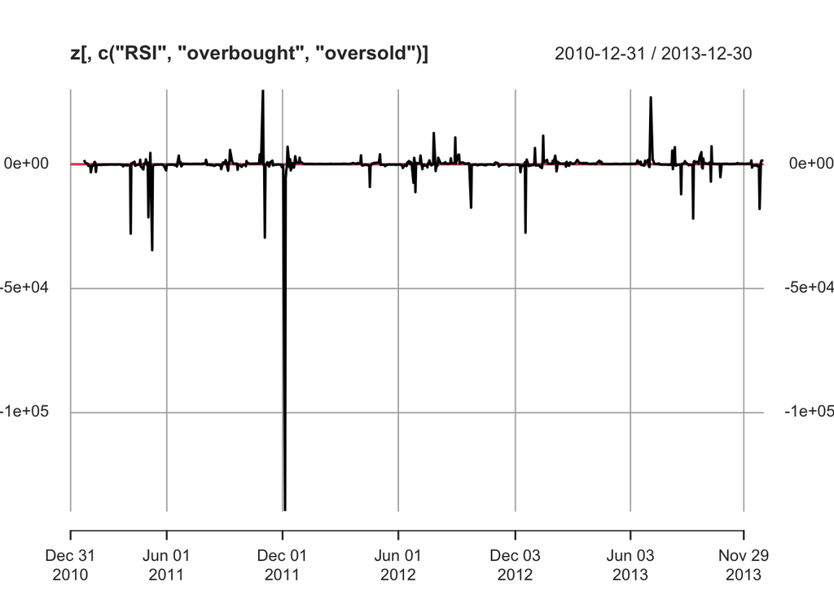

```r
plot(z[,c("RSI","overbought","oversold")])
```

### Make it a function!

```r
myRSI=function(stock_data2){


z=Cl(stock_data2)
names(z)="price"

z$delta=diff(z$price)

z$up=ifelse(z$delta>0,1,0)
z$dw=ifelse(z$delta<0,1,0)


z$up.val=z$delta*z$up
z$dw.val=z$delta*z$dw

z$up.avg=NA
z$up.avg[15]=mean(z$up.val[2:15])
z$dw.avg=NA
z$dw.avg[15]=mean(z$dw.val[2:15])

for(i in 16:nrow(z)){
z$up.avg[i]=(as.numeric(z$up.avg[i-1])*13+as.numeric(z$up.val[i])*1)/14
z$dw.avg[i]=(as.numeric(z$dw.avg[i-1])*13+as.numeric(z$dw.val[i])*1)/14
}

z$RS=z$up.avg/z$dw.avg

z$RSI=100-100/(1+z$RS)

return(z$RSI)
}
```

Later we will see how one can use a custom function like this one in constructing trading strategy for backtesting!

### Test the function

Use your function to calculate RSI and plot it:

```r
myRSI(stock_data2)
```

```
##                      RSI
## 2010-12-31            NA
## 2011-01-03            NA
## 2011-01-04            NA
## 2011-01-05            NA
## 2011-01-06            NA
## 2011-01-07            NA
## 2011-01-10            NA
## 2011-01-11            NA
## 2011-01-12            NA
## 2011-01-13            NA
## 2011-01-14            NA
## 2011-01-18            NA
## 2011-01-19            NA
## 2011-01-20            NA
## 2011-01-21    1736.36091
## 2011-01-24     461.66942
## 2011-01-25     410.94638
## 2011-01-26     281.62726
## 2011-01-27     261.85661
## 2011-01-28    -570.72263
## 2011-01-31    -537.83680
## 2011-02-01   -3199.71547
## 2011-02-02   -1716.33346
## 2011-02-03    -440.56301
## 2011-02-04    -708.30139
## 2011-02-07     986.94043
## 2011-02-08     724.51479
## 2011-02-09   -3086.62518
## 2011-02-10    -321.90413
## 2011-02-11    -212.74592
## 2011-02-14    -206.70699
## 2011-02-15    -146.32209
## 2011-02-16    -164.83737
## 2011-02-17    -256.12358
## 2011-02-18    -198.07617
## 2011-02-22    -112.23990
## 2011-02-23    -112.23990
## 2011-02-24    -162.82898
## 2011-02-25    -123.94330
```

[output cut: 700 more lines]

```
## 2013-12-09     244.48177
## 2013-12-10     442.77482
## 2013-12-11    1627.19202
## 2013-12-12   -1304.89618
## 2013-12-13    -358.76828
## 2013-12-16    -550.41514
## 2013-12-17    -300.40089
## 2013-12-18    -334.90049
## 2013-12-19    -221.73933
## 2013-12-20    -717.57922
## 2013-12-23    -465.00455
## 2013-12-24  -17955.74560
## 2013-12-26     819.63036
## 2013-12-27    1536.61408
## 2013-12-30    1536.61408
```